# Political Analysis - How Elections are Won

Sam Lee

2022-12-11

# Introduction

In this brief analysis we use data across various domains, including from the U.S. Census Bureau and the Pew Research Center to draw connections between a given voter’s party affiliation and election results. We will attempt to show how these fine lines painted in the first analysis can be shifted through the influence of independent voters.

## Analysis #1 - Population Density: The Fine Lines of Party Affiliation

#### Expected Correlation between Population Density and Party Affiliation

[figure not shown]

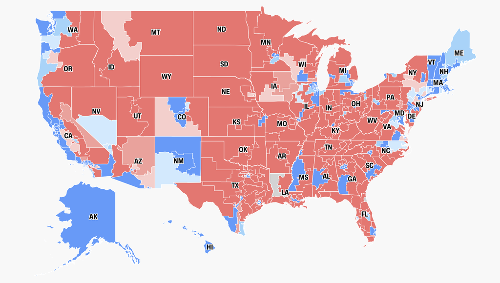

According to this basic assumption, we would assume that the any general election would reflect the U.S. general population density distribution map$_1$.

The map, outlined on the right$_2$ reflects. the results of the 2022 Midterm races that happened in the House.

The following table$_3$ maps out each state with respect to their population and population densities. The data for party affiliation comes from samples from the [Pew Research Center](https://www.pewresearch.org/religion/religious-landscape-study/compare/party-affiliation/by/state/).

Each U.S. state mapped acording to their population density (as of 2020) and respective political affiliation proportions.

| State | Population | Density | Republican | Independent | Democrat |
| --- | --- | --- | --- | --- | --- |
| Alabama | 5024279 | 99.2 | 0.52 | 0.13 | 0.35 |
| Alaska | 733391 | 1.3 | 0.39 | 0.29 | 0.32 |
| Arizona | 7151502 | 62.9 | 0.40 | 0.21 | 0.39 |
| Arkansas | 3011524 | 57.9 | 0.46 | 0.16 | 0.38 |
| California | 39538223 | 253.7 | 0.30 | 0.21 | 0.49 |
| Colorado | 5773714 | 55.7 | 0.41 | 0.17 | 0.42 |
| Connecticut | 3605944 | 744.7 | 0.32 | 0.18 | 0.50 |
| Delaware | 989948 | 508.0 | 0.29 | 0.17 | 0.55 |
| Florida | 21538187 | 401.4 | 0.37 | 0.19 | 0.44 |
| Georgia | 10711908 | 185.6 | 0.41 | 0.18 | 0.41 |
| Hawaii | 1455271 | 226.6 | 0.28 | 0.20 | 0.51 |
| Idaho | 1839106 | 22.3 | 0.49 | 0.19 | 0.32 |
| Illinois | 12812508 | 230.8 | 0.33 | 0.19 | 0.48 |
| Indiana | 6785528 | 189.4 | 0.42 | 0.20 | 0.37 |
| Iowa | 3190369 | 57.1 | 0.41 | 0.19 | 0.40 |
| Kansas | 2937880 | 35.9 | 0.46 | 0.23 | 0.31 |
| Kentucky | 4505836 | 114.1 | 0.44 | 0.13 | 0.43 |
| Louisiana | 4657757 | 107.8 | 0.41 | 0.16 | 0.43 |
| Maine | 1362359 | 44.2 | 0.36 | 0.17 | 0.47 |
| Maryland | 6177224 | 636.1 | 0.31 | 0.14 | 0.55 |
| Massachusetts | 7029917 | 901.2 | 0.27 | 0.17 | 0.56 |
| Michigan | 10077331 | 178.0 | 0.34 | 0.19 | 0.47 |
| Minnesota | 5706494 | 71.7 | 0.39 | 0.15 | 0.46 |
| Mississippi | 2961279 | 63.1 | 0.44 | 0.14 | 0.42 |
| Missouri | 6154913 | 89.5 | 0.41 | 0.18 | 0.42 |
| Montana | 1084225 | 7.4 | 0.49 | 0.21 | 0.30 |
| Nebraska | 1961504 | 25.5 | 0.47 | 0.17 | 0.36 |
| Nevada | 3104614 | 28.3 | 0.37 | 0.18 | 0.46 |
| New Hampshire | 1377529 | 153.8 | 0.35 | 0.20 | 0.44 |
| New Jersey | 9288994 | 1263.0 | 0.30 | 0.19 | 0.51 |
| New Mexico | 2117522 | 17.5 | 0.37 | 0.15 | 0.48 |
| New York | 20201249 | 428.7 | 0.28 | 0.19 | 0.53 |
| North Carolina | 10439388 | 214.7 | 0.41 | 0.17 | 0.43 |
| North Dakota | 779094 | 11.3 | 0.50 | 0.18 | 0.33 |
| Ohio | 11799448 | 288.8 | 0.42 | 0.18 | 0.40 |
| Oklahoma | 3959353 | 57.7 | 0.45 | 0.15 | 0.40 |
| Oregon | 4237256 | 44.1 | 0.32 | 0.21 | 0.47 |
| Pennsylvania | 13002700 | 290.6 | 0.39 | 0.15 | 0.46 |
| Rhode Island | 1097379 | 1061.4 | 0.30 | 0.22 | 0.48 |
| South Carolina | 5118425 | 170.2 | 0.43 | 0.18 | 0.39 |
| South Dakota | 886667 | 11.7 | 0.53 | 0.10 | 0.37 |
| Tennessee | 6910840 | 167.6 | 0.48 | 0.15 | 0.36 |
| Texas | 29145505 | 111.6 | 0.39 | 0.21 | 0.40 |
| Utah | 3271616 | 39.7 | 0.54 | 0.16 | 0.30 |
| Vermont | 643077 | 69.8 | 0.29 | 0.14 | 0.57 |
| Virginia | 8631393 | 218.6 | 0.43 | 0.18 | 0.39 |
| Washington | 7705281 | 115.9 | 0.33 | 0.23 | 0.44 |
| West Virginia | 1793716 | 74.6 | 0.43 | 0.16 | 0.41 |
| Wisconsin | 5893718 | 108.8 | 0.42 | 0.16 | 0.42 |
| Wyoming | 576851 | 5.9 | 0.57 | 0.18 | 0.25 |

The theory behind this analysis is to imply that conservative leaning individuals, typically located in less densely populated areas, will show more concern towards areas of policy that concern less densely populated ares (agriculture, land ownership rights, property taxes, etc.)

On the other hand, left-leaning individuals who typically live in more densely populated areas will show interest in policies that concern population centers. Education policies, social issues, and crime reform may be included.

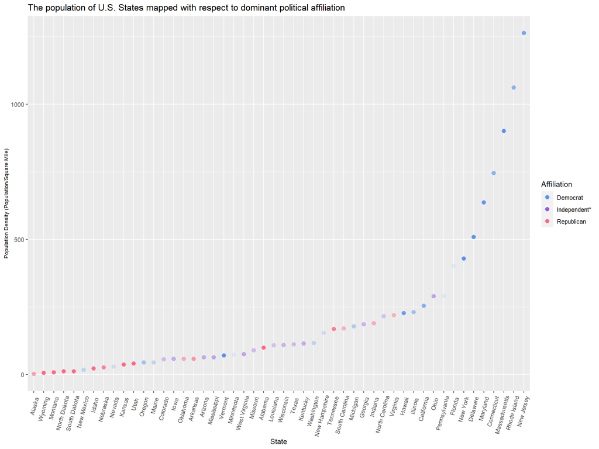

*An Independent state is defined as a state where the the proportion of Republican and Democrat voters are within 2.5 percentage points.

#### Conclusion

While there is a bit of variability with states in the middle quartiles, it is clear that that the states with the highest population densities tend lean Democrat, while the states with the lowest population densities tend to lean Republican.

The limitation with this analysis is that while it can generalize party affiliation in a given area based on population density, suggesting that those with similar values tend to live in similar areas, it does an incredibly poor job of explaining the variance that happens from general election to general election, or even worse, what happens in state and local elections. Therefore, there are other factors at play that can (A) sway voters from one party to another, particularly voters that live in “purple” or independent* states, or (B) there are other socioeconomic factors that affect a voter’s party affiliation.

## Analysis #2: Do Independent Votes Count?

#### How much did the independent voters affect this election?

Below is a table of the 31 states that allow voters to indicate party affiliation on voter registration forms

| State | Total Registrants | Democratics | Republicans | Independents | Other |
| --- | --- | --- | --- | --- | --- |
| Alaska | 599465 | 76948 | 143632 | 348199 | 30685 |
| Arizona | 4290348 | 1334001 | 1478781 | 1442812 | 34753 |
| Arkansas | 1765681 | 88508 | 123726 | 1552654 | 792 |
| California | 21941212 | 10261984 | 5249974 | 5096197 | 1333056 |
| Colorado | 3795559 | 1043269 | 938384 | 1745466 | 68439 |
| Connecticut | 2472466 | 905268 | 497981 | 1028066 | 41150 |
| Delaware | 760788 | 362002 | 209358 | 173663 | 15764 |
| Florida | 14395281 | 4963722 | 5233366 | 3939389 | 258803 |
| Idaho | 992332 | 128832 | 574005 | 274417 | 15077 |
| Iowa | 2223700 | 702652 | 761450 | 739850 | 19747 |
| Kansas | 1951099 | 503746 | 858429 | 565871 | 23052 |
| Kentucky | 3573760 | 1605744 | 1618444 | 139078 | 210493 |
| Louisiana | 3006527 | 1190831 | 1002624 | 813071 | 0 |
| Maine | 1114582 | 395893 | 313866 | 358909 | 45913 |
| Maryland | 4140894 | 2240975 | 995286 | 834325 | 70307 |
| Massachusetts | 4838359 | 1434356 | 436379 | 2911268 | 56355 |
| Nebraska | 1240158 | 345268 | 604988 | 268291 | 21610 |
| Nevada | 2169364 | 718424 | 637530 | 640961 | 172448 |
| New Hampshire | 1044108 | 326735 | 309281 | 408091 | 0 |
| New Jersey | 6475638 | 2531848 | 1524185 | 2338648 | 80956 |
| New Mexico | 1353869 | 600453 | 421422 | 303621 | 28372 |
| New York | 12975047 | 6459542 | 2841286 | 2996889 | 677329 |
| North Carolina | 7374566 | 2492551 | 2216022 | 2616059 | 49933 |
| Oklahoma | 2272602 | 697141 | 1151026 | 405010 | 19424 |
| Oregon | 2971604 | 1011945 | 729316 | 1031569 | 198773 |
| Pennsylvania | 8766097 | 4003126 | 3462803 | 926826 | 373341 |
| Rhode Island | 712945 | 290805 | 97879 | 324260 | 0 |
| South Dakota | 589363 | 150760 | 291956 | 142538 | 4108 |
| Utah | 1894316 | 268576 | 956364 | 561031 | 108344 |
| West Virginia | 1146071 | 380765 | 447984 | 267355 | 49966 |
| Wyoming | 295198 | 30271 | 235298 | 26866 | 2762 |

*Data courtesy of [Ballotopedia](https://ballotpedia.org/Partisan_affiliations_of_registered_voters)$_4$

Total Proportion of Independent Voters within these 31 States: 28.602%

As estimated by the Pew Research Center: 18.387%

Estimate of Independent Voters in the U.S. as a whole according the Pew Research Center: 18.464%

One reason why the Pew Research Center’s estimate of independent voters may underestimate the true proportion of registered voters is because those registered as “independent” in the 31 states where registering as an independent is allowed may actually be more left or right leaning when sampled. In other words, a center-right voter may have registered as an independent in Utah, but when sampled by the Pew Research Center, they may have indicated themselves as a Republican voter as that is what they will vote in a pluralistic amount of races.

Highest proportion of Independent voters in each state*

| State | Independents |
| --- | --- |
| Arkansas | 87.935% |
| Massachusetts | 60.171% |
| Alaska | 58.085% |
| Colorado | 45.987% |
| Rhode Island | 45.482% |
| Connecticut | 41.581% |
| New Hampshire | 39.085% |
| New Jersey | 36.115% |
| North Carolina | 35.474% |
| Oregon | 34.714% |
| Arizona | 33.629% |
| Iowa | 33.271% |
| Maine | 32.201% |
| Utah | 29.617% |
| Nevada | 29.546% |
| Kansas | 29.003% |
| Idaho | 27.654% |
| Florida | 27.366% |
| Louisiana | 27.044% |
| South Dakota | 24.185% |
| West Virginia | 23.328% |
| California | 23.227% |
| New York | 23.097% |
| Delaware | 22.827% |
| New Mexico | 22.426% |
| Nebraska | 21.634% |
| Maryland | 20.148% |
| Oklahoma | 17.821% |
| Pennsylvania | 10.573% |
| Wyoming | 9.101% |
| Kentucky | 3.892% |

*As of October of 2022

## Closest Races from the 2022 Midterms

All close races from the 2022 Midterm Elections*

| State | District | Victor | Margin | Type | Independents |
| --- | --- | --- | --- | --- | --- |
| COLORADO | CO-3 | R | 0.2 | House | 45.987 |
| CALIFORNIA | CA-13 | R | 0.4 | House | 23.227 |
| +MICHIGAN | MI-10 | R | 0.5 | House | 18.000 |
| ARIZONA | - | D | 0.6 | Governor | 33.629 |
| IOWA | IA-3 | R | 0.6 | House | 33.271 |
| NEW MEXICO | NM-2 | D | 0.6 | House | 22.426 |
| COLORADO | CO-8 | D | 0.7 | House | 45.987 |
| ARIZONA | AZ-1 | R | 0.8 | House | 33.629 |
| CONNECTICUT | CT-5 | D | 0.8 | House | 41.581 |
| NEW YORK | NY-17 | R | 0.8 | House | 23.097 |
| +WASHINGTON | WA-3 | D | 0.8 | House | 19.000 |
| NEVADA | - | D | 0.9 | Senate | 29.546 |
| +WISCONSIN | - | R | 1.0 | Senate | 23.000 |
| NEW YORK | NY-18 | D | 1.0 | House | 23.097 |
| NEW YORK | NY-22 | R | 1.0 | House | 23.097 |
| +GEORGIA | - | D | 1.2 | Senate | 16.000 |
| NEVADA | - | R | 1.4 | Governor | 29.546 |
| ARIZONA | AZ-6 | R | 1.4 | House | 33.629 |
| OREGON | OR-5 | R | 2.0 | House | 34.714 |
| PENNSYLVANIA | PA-7 | D | 2.0 | House | 10.573 |
| KANSAS | - | D | 2.1 | Governor | 29.003 |
| NEW YORK | NY-19 | R | 2.2 | House | 23.097 |
| CALIFORNIA | CA-34 | D | 2.4 | House | 23.227 |
| PENNSYLVANIA | PA-8 | D | 2.4 | House | 10.573 |
| OREGON | OR-6 | D | 2.5 | House | 34.714 |

*A close race is define as whether a the victor is determined within 2.5 percentage points.

Data in this data set is primarily taken from Politico$_5$, supplemented with data from Ballotpedia$_4$, and the Pew Research Center$_3$.

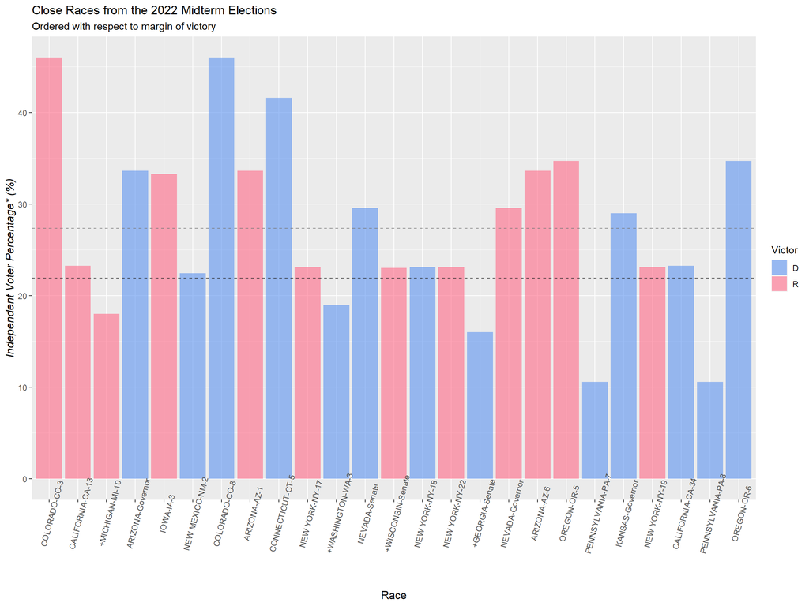

*Independent voter percentage is based off of registered voters from the 31 states where it’s possible to indicate “Independent” as a valid party affiliation. States annotated with a (+) do not have Independent party affiliation voter registry privileges. Estimates from the Pew Research Center are used instead.

Average mean of independent voters in key elections from the 2022 Midterms: 27.346%

Average national mean (excluding statistics from key elections & filtered out for outliers): 21.887%

An outlier would be a state like Arkansas since it is a solid (R) state despite it having an unusual high independent voter population. That statistic also disagrees with the Pew Research Center’s estimate thus prompting further investigation.

In this final analysis we will see if there is a (significant) discrepancy between the percentage of Independent voters in the close race samples compared to the expected percentage of independent voters.

Essentially what we’re asking is did the independent voters in the sample make a significant difference in the election outcomes? Or is it more or less representative of any given election result.

`T-test for unequal variance`

`t-statistic =` 2.110498 `Degrees of freedom =` 52.5377309

#### Conclusion

##### Data Sources

###### [1] U.S. Census Bureau

- https://www.census.gov/library/visualizations/2021/geo/population-distribution-2020/_jcr_content/root/responsivegrid/embeddableimage1160.coreimg.jpeg/1632836768476/2020popdist.jpeg
- https://www.census.gov/data/tables/time-series/dec/density-data-text.html

###### [2] CNN

- https://www.cnn.com/election/2022/results/house?election-data-id=2022-HG&election-painting-mode=projection&filter-key-races=false&filter-flipped=false

###### [3] Pew Research Center

- https://www.pewresearch.org/religion/religious-landscape-study/compare/party-affiliation/by/state/

###### [4] Ballotopedia

- https://ballotpedia.org/Partisan_affiliations_of_registered_voters

###### [5] Politico

- https://www.politico.com/2022-election/results/